# Homework 2

Ezana Rivers

02-10-2026

# 1 Introduction

This note covers the definitions and inter-relationships of normal, t, chi-square, and F distributions, and their assumptions.

# 2 Normal Distrubtions

A normal distribution is a parametric distribution. A parametric distribution assumes the shape of the distribution. In other words, a parametric model assumes how the data is organized to make analyses from.

A normal distribution assumes about:  
* 68% of data is 1 standard deviation of the mean  
* 95% of the data is 2 standard deviations of the mean  
* 99.7% of the data is 3 standard deviations of the mean  
(Wackery, Mendenhall, Scheaffer, 1945, p.10).

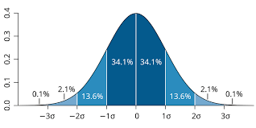

Normal Distrubtion

The assumed normal distribution takes on a bell curve. Demonstrated by the formula:

$$f(y) = \frac{1}{\sigma\sqrt{2\pi}} e^{-\frac{(y-\mu)^2}{2\sigma^2}}$$

Note: What is a standard deviation? - A standard deviation measures how much variation (or how dispersed) a set of values is from the mean. A lower standard deviation (ig. 1 standard deviation from the mean) is a value closer to the mean. A value closer the the mean as well as lower variance may suggest a stronger value or model. As lower variance may suggest points are clustered tightly around the the mean while higher variance suggests the data is spread out, potentially containing outliers.

## 2.1 Assumptions for Normal Distrubutions

1. Data is continuous
2. Symmetric with one peak
3. Bell Shaped
4. Mean, median and mode all assumed to be equal

# 3 Using Normal Distrubutions for Estimation

As the majority of random samples take on a normal distribution as using a parametric normal distribution as a sole estimator for a true Cumulative density function (CDF) should come with causation because assuming the shape of sample may add noise or bias into the estimator and or analysis, as adding a parameter test may not best hit the sample and or population.

-Note in most cases the population parameters and or distribution is unknown.

Although the majority of random samples take on a normal distribution inherently taking on a parametric distribution as a estimator for a true Cumulative density function (CDF), always assuming a normal distribution should come with caution. Assuming the shape of sample, when the sample distribution shape may be unknown may add noise or bias into the estimator and or analysis. The a parameter test may not best fit the sample and or population. If we force a bell-curve onto data that is actually skewed (leaning to one side instead of symmetric and non-naturally bell-shaped) our conclusions will hold bias.

Note in many cases the true population’s parameters or distributions are unknown so assuming shape may increase chance of error.

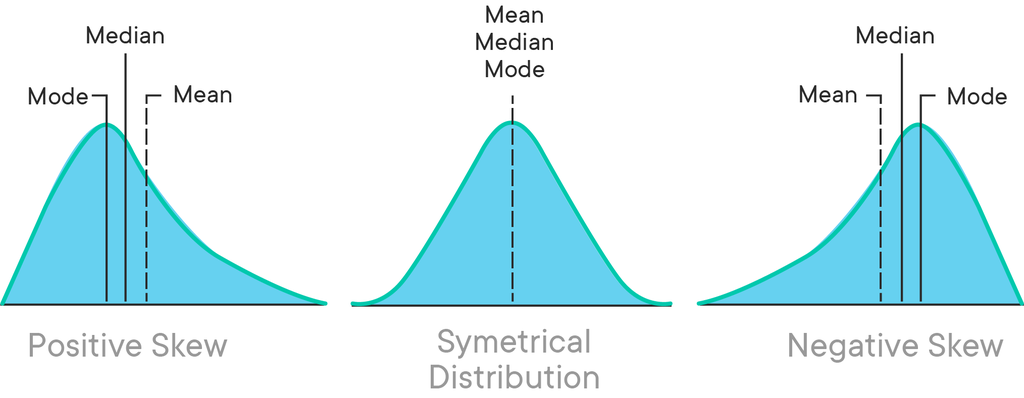

```r
# https://www.biologyforlife.com/skew.html

knitr::include_graphics("C:/Users/75ER969287/OneDrive - West Chester University of PA/STA 506 - Mathematical Statistics II/Weekly Modules/Week 3/Homework/skewness image image 2.png")
```

## 3.1 Normal Distrubution Advantages

Despite a normal distribution being a parametric distribution that assumes shape, there are many advantages to using a normal distribution.***********

Uses for a normal distribution

- A normal distribution has act as a comparison and validity checker
  - A normal distribution  
    Often the case for linear regression, t-test and ANOVA residual tests /
  - We will later discuss an normal distribution assumption to assess the quality of two models by their variance ratio, also known as an F distribution /
  - Overall we often use normal distribution as the bases to make conclusions or approximations about our distributions because often samples or population often approach normal distributions and we can standardize our distributions relatively easily to match a universal scale for standard deviations. Regardless of the data’s original units, we can standardize within our data to digest how rare or common a data point is in respect to the other values.
- Estimation for the Cumulative Distribution Function A normal distribution can act as an estimator for the cumulative distribution function. if an empirical CDF is used, the theoretical normal distribution function can be a base comparison to see if these two are statistically different.

In this case the empirical CDF is model based on the data observed. We can compare how well an empirical model compares to a theoretical normal distribution model to help us understand any nuance in our observed data.

```r
set.seed(45)
# Generate sample data
sample_data <- rnorm(100, mean = 0, sd = 1)

# Create empirical CDF
empirical_cdf <- ecdf(sample_data)

# Plot empirical vs theoretical CDF
plot_df <- data.frame(
  x = seq(-5, 5, length.out = 2500),
  Empirical = empirical_cdf(seq(-15, 15, length.out = 2500)),
  Theoretical = pnorm(seq(-15, 15, length.out = 2500))
)

plot_df_long <- plot_df %>%
  pivot_longer(cols = c(Empirical, Theoretical),
               names_to = "Type", values_to = "CDF")

Fn.plt <- ggplot(plot_df_long, aes(x = x, y = CDF, color = Type)) +
  geom_line(linewidth = 1) +
  scale_color_manual(values = c("Empirical" = "green", "Theoretical" = "purple")) +
  labs(title = "Empirical vs Theoretical CDF",
       subtitle = "Sample size n = 100 from Standard Normal",
       x = "x", y = "CDF") +
  theme(plot.title = element_text(hjust = 0.5),
        plot.margin = margin(t = 35, r = 20, b = 30, l = 30, unit = "pt"))
ggplotly(Fn.plt)
```

[interactive chart not shown]

While the Normal distribution is the foundation of parametric inference, it can be applied to describe a sampling distribution in two distinct capacities:

1. **Exact Distribution**: our population distribution is known to be normally distributed with random variables that are identically and independently distributed within a small sample size or

Because we know our population distribution is normal we can standardize our distribution sample to be under one.

$$Z = \frac{\bar{X} - \mu}{\sigma / \sqrt{n}} \rightarrow^d N(0,1)$$

2. **Asymptotic Distribution** our population distribution is unknown but our sample size is large

## 3.2 Extract Distrubtion

A exact distribution assumes a normally distributed population with random variables that are identically and independently distributed within a small sample size. Our random variables are collected and treated independently, as the probability of the one value does not effect the probability of the next value.

## 3.3 Asymptotic Distribution Relation in Normal Distrubution

As mentioned earlier, there are some advantages to using the normal distribution despite its shape assumption.

As we take a random sample from the population in which we are not sure of its distribution, we use the normal distribution as an approximation for the true distribution.

Due to the large sample size, we can use the Central Limit Theorem to assume our sample statistic (often our sample mean) approaches and reaches a normal distribution. Even if in smaller quantities the distribution may not appear normal, with a large sample size our distribution my converge to a normal distribution. If an original population contains skew in its distribution, with a large enough sample the distribution can place into a bell curve.

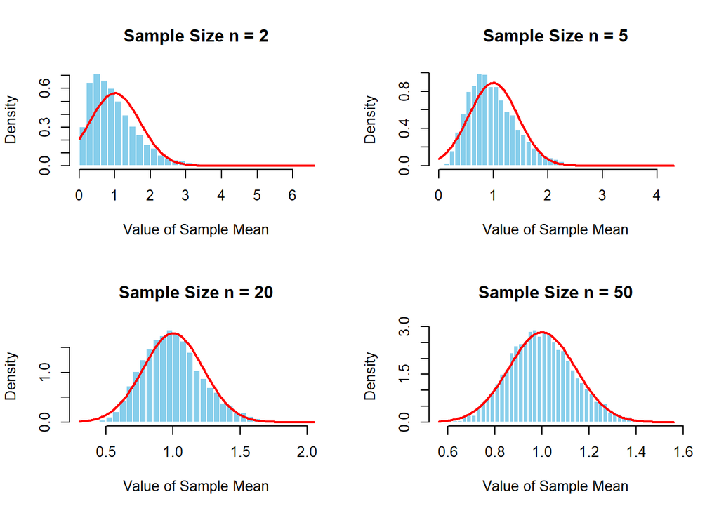

```r
# Set a seed so the random results are the same every time you 'knit'
set.seed(12)

# Define number of simulations and different sample sizes to test
n_simulations <- 10000
sample_sizes <- c(2, 5, 20, 50)

# Set up a 2x2 grid for the graphs
par(mfrow = c(2, 2))

for (n in sample_sizes) {
  # 1. Take 10,000 random samples of size 'n' from a skewed population
  # 2. Calculate the mean for each of those 10,000 samples
  sample_means <- replicate(n_simulations, mean(rexp(n, rate = 1)))

  # 3. Create the histogram
  hist(sample_means,
       breaks = 40,
       freq = FALSE,
       main = paste("Sample Size n =", n),
       xlab = "Value of Sample Mean",
       col = "skyblue",
       border = "white")

  # 4. Add a theoretical Normal Curve (Red line) to see the fit
  # The mean of our population is 1, and SD is 1.
  curve(dnorm(x, mean = 1, sd = 1/sqrt(n)),
        add = TRUE, col = "red", lwd = 2)
}
```

In these images we see as the sample size (n) increases,the distribution to moves to be less skewed into a more normal distribution.

As the observed distribution, may not follow a normal distribution directly we standardize our values into a normal distribution, using the following formula. Note this formula is an approximation. An approximation acts as best estimate considering we do not know the true distribution, unlike the exact distribution.

$$Z = \frac{\bar{X} - \mu}{\sigma / \sqrt{n}} \rightarrow^{aprox} N(0,1)$$

By standardizing our values into Z scores, we can approximate our probability distribution sample statistics, which are values like the mean, proportion, or regression coefficient.